# Multivariate statistics II: PCR and PLSR

Mar 18 2025

## Topics for this lecture

- Motivation for dimension reduction in regression
- Principal Components regression (PCR)
- Partial Least Squares Regression (PLSR)

## Motivation for dimension reduction in regression

- The ordinary least squares estimator is much used since:
  1. It is an unbiased estimator
  2. Among all unbiased estimators it has minimum variance
- However, it has some problems:
  1. Requires \(n>p\) (more observations than variables)
  2. May suffer from inflated variances when \(n \sim p\), or…
  3. …if the predictors are highly collinear

## Example - Chemometrics/Spectroscopy

- Near Infra Red (NIR)-spectroscopy absorbance spectra.
- \(p=700\) wavelenghts for \(n=100\) samples.

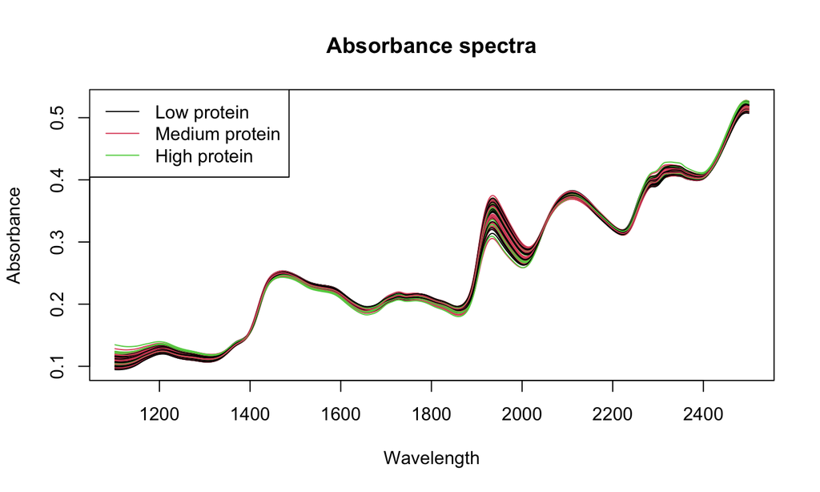

## OLS under multi-collinearity, I

- Regression with one wavelength, w1522

```
##
## Call:
## lm(formula = Absorbance ~ NIR.w1522, data = NIRdata)
##
## Residuals:
##      Min       1Q   Median       3Q      Max
## -1.68013 -0.52481 -0.03636  0.49450  1.56003
##
## Coefficients:
##             Estimate Std. Error t value Pr(>|t|)
## (Intercept)    38.77       7.48   5.184 1.17e-06 ***
## NIR.w1522    -132.94      31.88  -4.169 6.60e-05 ***
## ---
## Signif. codes:  0 '***' 0.001 '**' 0.01 '*' 0.05 '.' 0.1 ' ' 1
##
## Residual standard error: 0.7131 on 98 degrees of freedom
## Multiple R-squared:  0.1507, Adjusted R-squared:  0.142
## F-statistic: 17.38 on 1 and 98 DF,  p-value: 6.598e-05
```

## OLS under multi-collinearity, II

- Regression with two highly correlated predictors

```
##
## Call:
## lm(formula = Absorbance ~ NIR.w1522 + NIR.w1532, data = NIRdata)
##
## Residuals:
##     Min      1Q  Median      3Q     Max
## -1.3721 -0.4781 -0.1079  0.4943  1.5716
##
## Coefficients:
##              Estimate Std. Error t value Pr(>|t|)
## (Intercept)    54.904      8.701   6.310 8.34e-09 ***
## NIR.w1522   -2052.372    592.367  -3.465 0.000792 ***
## NIR.w1532    1878.503    578.968   3.245 0.001614 **
## ---
## Signif. codes:  0 '***' 0.001 '**' 0.01 '*' 0.05 '.' 0.1 ' ' 1
##
## Residual standard error: 0.6808 on 97 degrees of freedom
## Multiple R-squared:  0.2338, Adjusted R-squared:  0.218
## F-statistic:  14.8 on 2 and 97 DF,  p-value: 2.456e-06
```

## A graphical view of multicollinearity

```r
library(rgl)
attach(NIRdata)
plot3d(NIR.w1522, NIR.w1532, Absorbance, col= "blue", radius=0.05, type="s", xlab="w1522", ylab="w1524", zlab="Absorbance")
detach(NIRdata)
```

## 3D plot

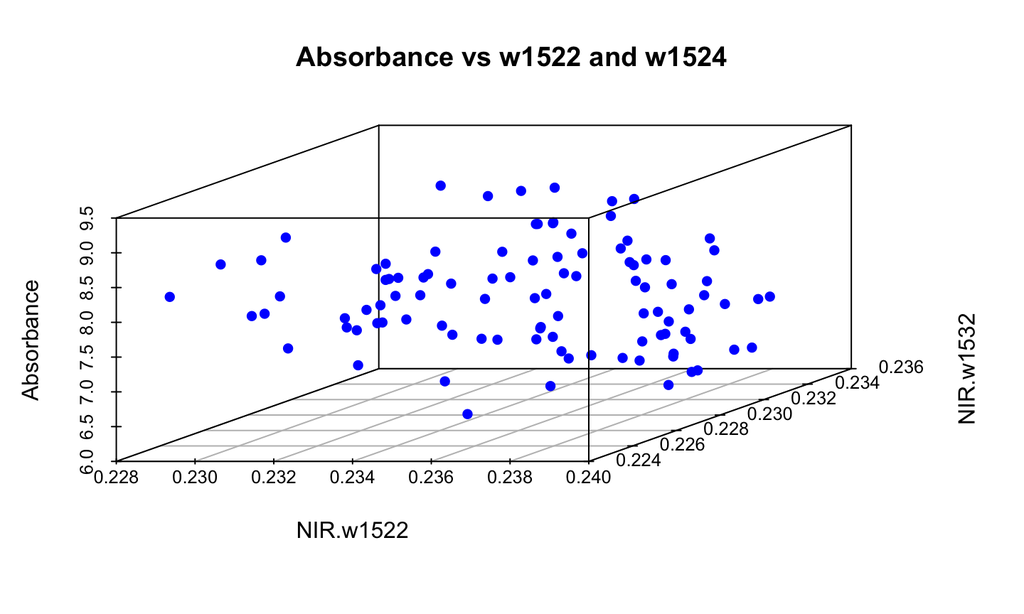

## OLS and overfitting

```r
vars <- sample(2:701, 50, replace=FALSE)
fmla <- as.formula(paste("Absorbance ~ ", paste(names(NIRdata)[vars], collapse= "+")))
lmfit3 <- lm(fmla, data=NIRdata)
res <- summary(lmfit3)
res$r.squared
res$adj.r.squared
```

```
## [1] 0.926543
```

```
## [1] 0.851587
```

## How to handle these problems

- Forward variable selection in OLS? (data reduction)
- Use alternative estimator, e.g. PCR or PLSR (data reduction to ‘principal components’)

## PCA of NIR data

- Let’s return to the 3D plot from above
- Locate the principal components
- Discuss the variances of the two principal components
- How many PC’s are needed to capture 99% of the variability in the entire NIR data?

## PCR

- In PCR the principal components (PCs) replace the original X-variables as predictors in regression.
- Let \(a\) be the number of PCs we choose to use (e.g. explaining 99% X-variability)
- Typically we use \(a<<k\) components in the model.

The model with \(a\) components:

\[Y = \alpha_0 + \alpha_1 Z_1 + \alpha_2 Z_2 \cdots+ \alpha_a Z_a +\epsilon\]

- The \(\alpha\)’s are estimated by the Ordinary Least Squares method.

## Example, NIR data

- Run PCA on the Wavelength data, check results, scree plot

```r
pcafmla <- as.formula(paste("~ ", paste(colnames(NIRdata)[2:600], collapse= "+")))
PCAModel.3 <- prcomp(pcafmla, scale.= FALSE, data=NIRdata)
screeplot(PCAModel.3)
```

## The Scree plot

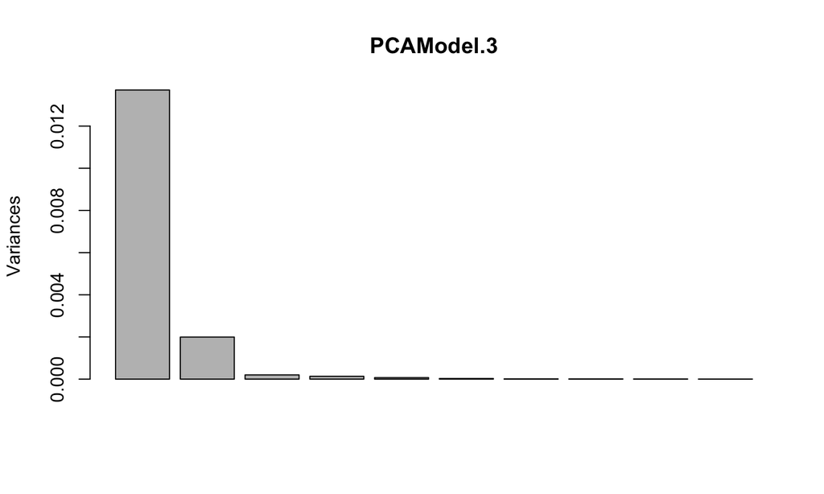

## Saving some principal components as extra variables to the data

```r
  PCAdata <<- within(NIRdata, {
    PC5 <- PCAModel.3$x[,5]
    PC4 <- PCAModel.3$x[,4]
    PC3 <- PCAModel.3$x[,3]
    PC2 <- PCAModel.3$x[,2]
    PC1 <- PCAModel.3$x[,1]
  })
```

## Regression model, PC1-PC5

```r
LinearModel.4 <- lm(Y ~ PC1 + PC2 + PC3 + PC4 + PC5, data=PCAdata)
sumfit <- summary(LinearModel.4)
round(sumfit$coefficients,3)
```

```
##             Estimate Std. Error t value Pr(>|t|)
## (Intercept)    7.588      0.052 145.807    0.000
## PC1            0.151      0.447   0.337    0.737
## PC2            4.061      1.171   3.468    0.001
## PC3           30.149      3.680   8.192    0.000
## PC4            3.063      4.520   0.678    0.500
## PC5           40.787      6.224   6.553    0.000
```

- Note that PC1 is not significant

## Running the PCR in RStudio with the pls package

- After estimation of the \(\alpha\)’s the regression coefficients for the *original* variables may be computed by a reverse transformation.
- These are easiest computed using the `pcr` function in the `pls` package.

```r
library(pls)
pcrfit <- pcr(Absorbance ~ ., data=NIRdata, scale=FALSE)
summary(pcrfit)
coefs.pc11 <- coef(pcrfit, 11)
```

## The regression coefficients plotted

- Here are the coefficients based on 11 PC’s

[figure not shown]

## Better to be presisly wrong…

…than approximately right

The PCR-estimates for the model with original predictors has typically these properties:

- They are biased if \(a<k\) (but being closer to zero than OLS)
- Have smaller variances than the least squares estimates.

Prediction error may be smaller for PCR than OLS model since:

Expected squared prediction error =

\(\sigma^2\) + var(estimates) + bias(estimates)\(^2\)

## Choosing the number of components, \(a\)

- Cross-validation. As Leave-one-out (LOO-CV), or K-fold.
- Root Mean Squared Error of Prediction (RMSEP)

\[RMSEP_{LOO-CV} = \sqrt{\frac{1}{n}\sum_{i=n}^{n}(y_{i}-\hat{y}_{(i)})^2}\] where \(\hat{y}_{(i)}\) is a prediction of \(y_{i}\) based on a data set where observation \(i\) has been left out.

- Compare RMSEP for \(a=1,2,\ldots\) and choose a simple, but good predictor.

## LOO-CV example - R-code

```r
MVRModel.7 <- pcr(Absorbance ~ ., data=NIRdata, scale=FALSE, ncomp=15, validation="LOO")
summary(MVRModel.7)
```

## Summary with RMSEP-values

```
## Data:    X dimension: 100 700
##  Y dimension: 100 1
## Fit method: svdpc
## Number of components considered: 15
##
## VALIDATION: RMSEP
## Cross-validated using 100 leave-one-out segments.
##        (Intercept)  1 comps  2 comps  3 comps  4 comps  5 comps  6 comps
## CV          0.7737   0.7805   0.7668   0.6406   0.6364   0.5576   0.5386
## adjCV       0.7737   0.7804   0.7667   0.6401   0.6363   0.5575   0.5385
##        7 comps  8 comps  9 comps  10 comps  11 comps  12 comps  13 comps
## CV      0.5499   0.5005   0.4381    0.4328    0.3978    0.4046    0.3979
## adjCV   0.5497   0.5003   0.4375    0.4326    0.3975    0.4044    0.3976
##        14 comps  15 comps
## CV       0.4041    0.3974
## adjCV    0.4038    0.3971
##
## TRAINING: % variance explained
##              1 comps  2 comps  3 comps  4 comps  5 comps  6 comps  7 comps
## X           84.80628   96.599    97.82    98.86    99.44    99.66    99.74
## Absorbance   0.09501    5.334    35.27    37.55    52.14    56.57    56.74
##             8 comps  9 comps  10 comps  11 comps  12 comps  13 comps  14 comps
## X             99.81    99.86      99.9     99.93     99.95     99.96     99.97
## Absorbance    65.32    74.00      75.2     79.34     79.43     80.42     80.62
##             15 comps
## X              99.98
## Absorbance     81.78
```

## Plotting RMSEP

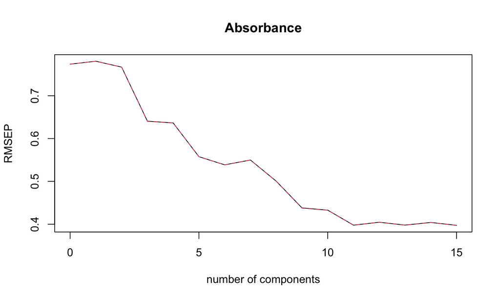

```r
plot(RMSEP(MVRModel.7))
```

## Partial Least Squares Regression

A problem with PCR is that the PC’s may not be good predictors for a response variable.

Partial Least Squares, on the other hand, is seeking PC’s that

- have maximum *covariance* between predictors and the response
- are orthogonal to each other
- search more directly for y-relevant information for prediction

## An example

Let’s sketch a situation were PLS will find other latent components than PCA

## Fitting the PLSR model in RStudio

```r
MVRModel.8 <- plsr(Absorbance ~ ., data=NIRdata, scale=FALSE, ncomp=15)
summary(MVRModel.8)
```

## Summary

```
## Data:    X dimension: 100 700
##  Y dimension: 100 1
## Fit method: kernelpls
## Number of components considered: 15
## TRAINING: % variance explained
##             1 comps  2 comps  3 comps  4 comps  5 comps  6 comps  7 comps
## X            45.489    95.56    97.74    98.35    98.76    99.53    99.71
## Absorbance    9.735    17.66    53.15    62.68    72.32    76.26    80.74
##             8 comps  9 comps  10 comps  11 comps  12 comps  13 comps  14 comps
## X             99.76    99.80     99.85     99.89     99.91     99.94     99.95
## Absorbance    83.11    85.33     86.83     87.75     88.68     89.11     90.35
##             15 comps
## X              99.97
## Absorbance     90.71
```

## Running LOO-CV and RMSEP plot

```r
MVRModel.8 <- plsr(Absorbance ~ ., data=NIRdata, scale=FALSE, ncomp=15, validation='LOO')
plot(RMSEP(MVRModel.8))
```

## The RMSEP plot

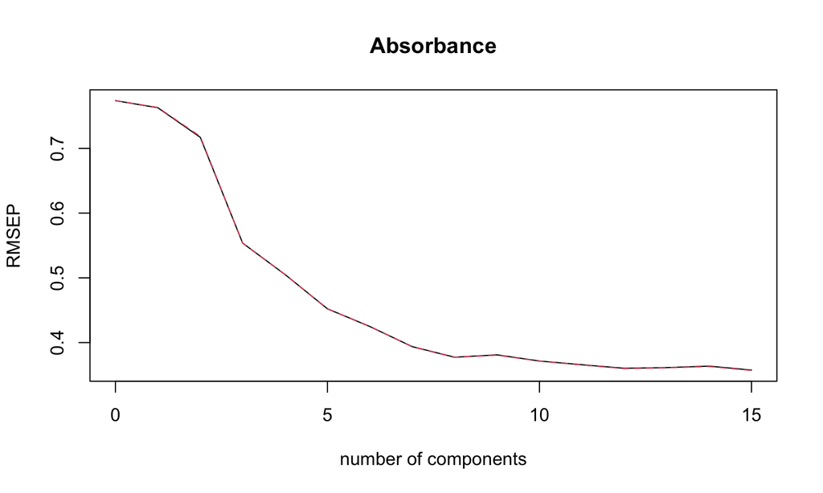

## The regression coefficients plotted

- Here are the coefficients based on 8 PLS PC’s

[figure not shown]

## Significance testing in PLSR

- No analytical expression for standard errors of estimates!
- No estimate of noise variance!
- Testing based on something called Jack-knifing

## Jack-knifing

- Leave-one-out method
- A estimate the variance of the regression coefficients is computed from the saved estimated coefficients from the \(n\) LOO-estimations.
- Readily computed in the `pls` package using the `jack.test` function.

\[Var(\hat{\beta}) = \frac{n-1}{n}\sum_{i=1}^{n}(\hat{\beta}_{(-i)} - \hat{\beta})^2\]

## Jack-knifing in RStudio

```r
MVRModel.8 <- plsr(Absorbance ~ ., data=NIRdata, scale=FALSE, ncomp=15, validation='LOO', jackknife=TRUE)
j.test <- jack.test(MVRModel.8, ncomp = 8, use.mean = FALSE)
print(j.test)
```

[output not shown]